# Sexual Dimorphism and Sexual Selection Tutorial

### Do larger birds have bigger clutches?

Is the size and weight of the bird at maturity related to the clutch size? Lets look at wing chord length, tail length, and bird weight to investigate this and lets separate our analysis my male and female birds

```r
# First, lets find the mean wing chord length when grouped by year, nest_box, sex, clutch_number, clutch_size and band number
# wing_chord
banding_nest.wing_chord <- aggregate(wing_chord ~ year + sex + nest_box + clutch_number + band_number + clutch_size, banding_nest, mean)
head(banding_nest.wing_chord)
```

```
##   year sex nest_box clutch_number band_number clutch_size wing_chord
## 1 2010   F    PT11K             1    1831.384           2        121
## 2 2010   M    PT11K             1    1881.064           2        125
## 3 2012   M     MC01             2    2401.772           2        116
## 4 2012   F     MC14             1    2401.772           2        118
## 5 2012   F     MC59             1    2401.772           2        118
## 6 2012   M     MC14             1    2401.779           2        119
```

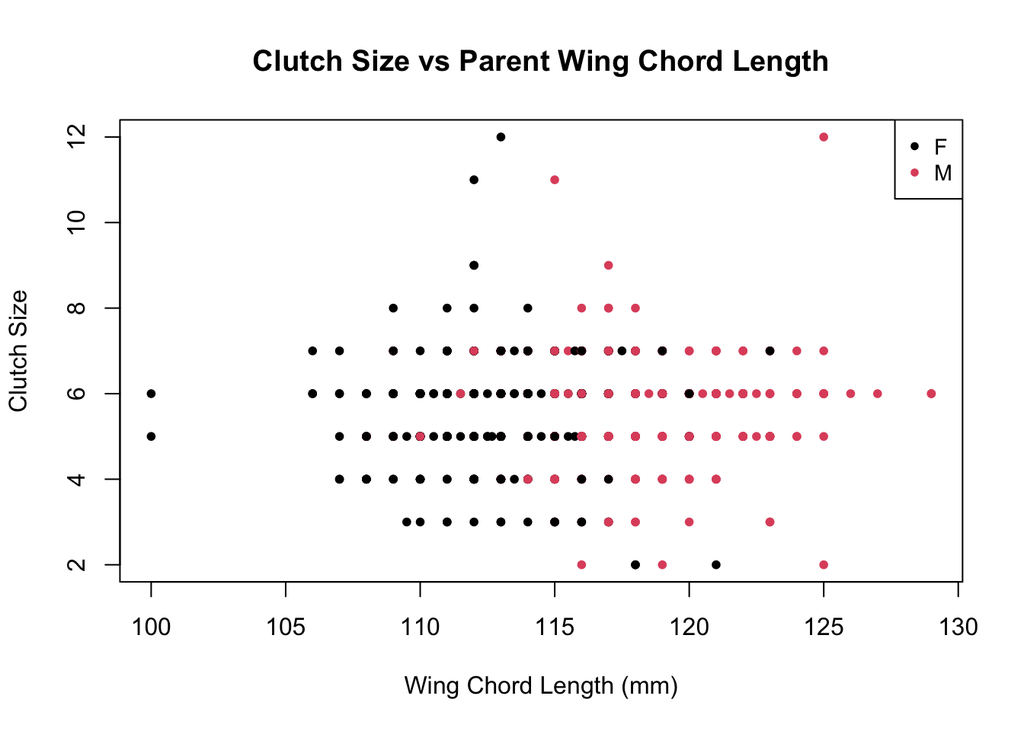

```r
# lets see if we see any patterns between the number of eggs there are per clutch (clutch_size) and the weight or size of the parent tree swallow
plot(clutch_size ~ wing_chord, banding_nest.wing_chord,
     main="Clutch Size vs Parent Wing Chord Length",
     pch=20,
     col=sex,
     xlab="Wing Chord Length (mm)",
     ylab="Clutch Size")
legend("topright", legend= levels(banding_nest.wing_chord$sex),
       col= 1:2, pch = 20, cex=0.9)
```

Now, you look at tail and weight variables. Compare your results to the results below.

**Hint** Use similar code to the code above, but change the variables to reflect what you are intersted in looking at.

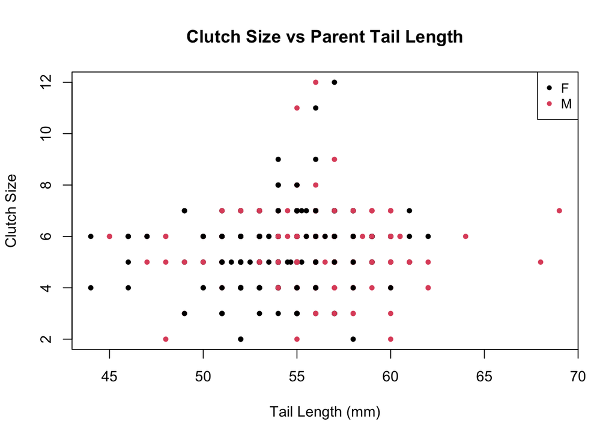

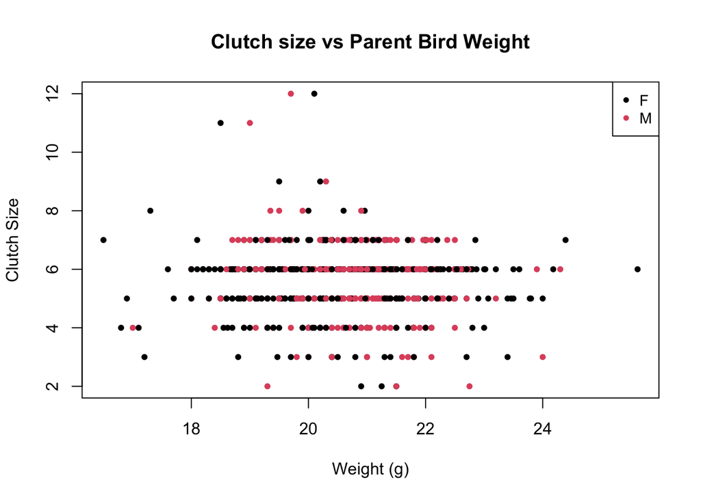

## Changes through time

Could bird communities be changing over time as a result of climate change or other environmental shifts? Lets observe if the average clutch size over time is changing.

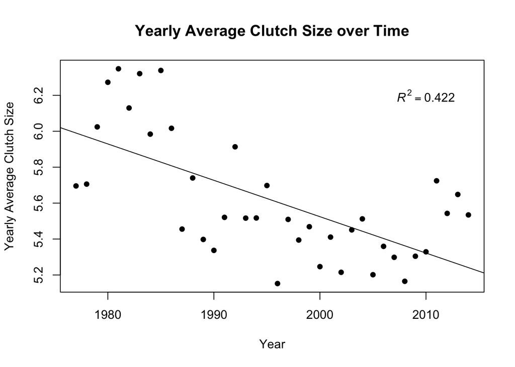

```r
# first we want to take the average clutch size that was sampled from all of the nest boxes each year
nest.average <- aggregate(clutch_size ~ year, nest, mean)
#Then, we'll run a linear regression to test the relationship between clutch size and year.
lm_clutch_size <- summary(lm(clutch_size ~ year, data= nest.average))
r2_0 <- lm_clutch_size$r.squared # for R-squared labels
rlabel_0 <- bquote(italic(R)^2 == .(format(r2_0, digits = 3)))
plot(clutch_size ~ year, data=nest.average,
     main="Yearly Average Clutch Size over Time",
     pch=16,
     xlab="Year",
     ylab="Yearly Average Clutch Size",
     cex.main=1.25,
     cex.lab=1)
abline(lm(clutch_size ~ year, data=nest.average))
text(2010, 6.2, rlabel_0)
```

It may appear that the average clutch size is declining overtime however when looking at the R^2 value of this linear regression we can see that this relationship is not a strong one.

## Take-homes

After going through these data you have now had the opportunity to learn a bit about tree swallows, and more specifically look at a ‘community’ of tree swallows found in Long Point, ON. This population appeared to show signs of sexual dimorphism, where the male swallows had longer wing chords and tails and were heavier. As well, we noticed that there appeared t be a trade off between clutch size and the number of clutched in a nest. An important thing to not is that these relationships were speculative and statistical analyses will be required to support these findings in this population.

Lastly, these data did not show trends of larger birds having more eggs and we observed no conclusive temporal trends of changes in birth rates over time. It is not uncommon that data is collected with certain hypotheses in mind and trend or relationships are ultimately not found to support these hypotheses!